# Seventh Week: Generalized Linear Models

Murder or suicide

Parand Alizadeh

2018-04-27 23:36:52

> با توجه به سوالات مرگ و میر در آمریکا به سوالات زیر پاسخ دهید.

۱. از میان متغیرهای داده مرگ و میر یک زیرمجموعه ایی بدون حشو در نظر بگیرید. ماتریس همبستگی متغیرهای مختلف را به دست آورده و سپس رسم نمایید. علاوه بر این نمودار پراکنش متغیرهای انتخاب شده را همزمان نسبت به هم رسم نمایید.

برای قسمت دوم به علت حجم زیاد داده و پارامترها از ۵درصد داده برای کشیدن نمودار استفاده شده است.

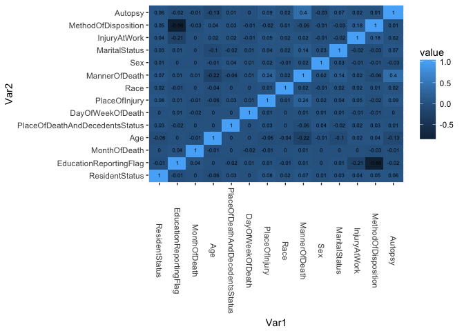

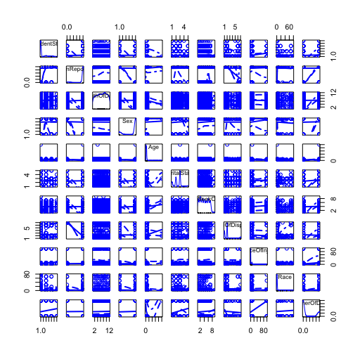

۲. اثر هر یک از متغیرهای جنسیت، نژاد،آموزش، سن و نحوه تدفین را بر مرگ یا خودکشی ارزیابی کنید.

برای ارزیابی تاثیر این متغیر ها از تست فرض استفاده شد (برای نژاد، آموزش تدفین و سن از تست آنوا) و نتایج آن در زیر مشاهده میشود. طبق p-value به دست آمده برای هر متغیر، فرض۰ رد میشود و همه این متغیر ها در نحوه مرگ تاثیر گذارند.

```
##
##  Welch Two Sample t-test
##
## data:  MannerOfDeath by Sex
## t = -4.983, df = 21842, p-value = 6.309e-07
## alternative hypothesis: true difference in means is not equal to 0
## 95 percent confidence interval:
##  -0.03026106 -0.01317523
## sample estimates:
## mean in group F mean in group M
##        2.263855        2.285574
```

```
##                Df Sum Sq Mean Sq F value   Pr(>F)
## Race            1      5   5.375   26.63 2.47e-07 ***
## Residuals   59977  12107   0.202
## ---
## Signif. codes:  0 '***' 0.001 '**' 0.01 '*' 0.05 '.' 0.1 ' ' 1
```

```
##                           Df Sum Sq Mean Sq F value  Pr(>F)
## EducationReportingFlag     1      2  1.5351   7.603 0.00583 **
## Residuals              59977  12110  0.2019
## ---
## Signif. codes:  0 '***' 0.001 '**' 0.01 '*' 0.05 '.' 0.1 ' ' 1
```

```
##                        Df Sum Sq Mean Sq F value Pr(>F)
## MethodOfDisposition     6    901  150.12     803 <2e-16 ***
## Residuals           59972  11211    0.19
## ---
## Signif. codes:  0 '***' 0.001 '**' 0.01 '*' 0.05 '.' 0.1 ' ' 1
```

```
##                Df Sum Sq Mean Sq F value Pr(>F)
## Age             1    574   573.8    2983 <2e-16 ***
## Residuals   59977  11538     0.2
## ---
## Signif. codes:  0 '***' 0.001 '**' 0.01 '*' 0.05 '.' 0.1 ' ' 1
```

۳. با استفاده از مدل رگرسیون لاجستیک یک مدل به داده ها برازش دهید و سپس آن را نقص یابی کنید.

```
##
## Call:
## glm(formula = MannerOfDeath ~ factor(Sex) + factor(Race) + factor(EducationReportingFlag) +
##     factor(MethodOfDisposition) + Age + factor(MaritalStatus) +
##     DayOfWeekOfDeath + factor(ResidentStatus), family = "binomial",
##     data = d)
##
## Deviance Residuals:
##     Min       1Q   Median       3Q      Max
## -2.3987  -0.6468  -0.4720   0.5596   5.6614
##
## Coefficients:
##                                   Estimate Std. Error z value Pr(>|z|)
## (Intercept)                     -0.9113518  0.3329221  -2.737  0.00619 **
## factor(Sex)M                    -0.2091865  0.0262477  -7.970 1.59e-15 ***
## factor(Race)2                    2.3588388  0.0276565  85.291  < 2e-16 ***
## factor(Race)3                    0.5195256  0.0786770   6.603 4.02e-11 ***
## factor(Race)4                   -0.2003201  0.1695580  -1.181  0.23743
## factor(Race)5                   -0.4088280  0.3648207  -1.121  0.26245
## factor(Race)6                    0.9415535  0.6624508   1.421  0.15522
## factor(Race)7                    0.2226870  0.1789934   1.244  0.21346
## factor(Race)18                   0.0804205  0.1854551   0.434  0.66455
## factor(Race)28                  -0.4324101  0.2146182  -2.015  0.04393 *
## factor(Race)38                   0.7062076  0.4389037   1.609  0.10761
## factor(Race)48                   0.4225080  0.1988594   2.125  0.03362 *
## factor(Race)58                  -1.0840452  1.0801269  -1.004  0.31556
## factor(Race)68                   0.2865740  0.1345135   2.130  0.03313 *
## factor(Race)78                   0.5917224  0.2121060   2.790  0.00527 **
## factor(EducationReportingFlag)1  0.4162541  0.3283765   1.268  0.20494
## factor(MethodOfDisposition)C    -0.7843368  0.0240548 -32.606  < 2e-16 ***
## factor(MethodOfDisposition)D    -1.2956206  0.2829260  -4.579 4.66e-06 ***
## factor(MethodOfDisposition)E    -0.2866307  0.1570733  -1.825  0.06803 .
## factor(MethodOfDisposition)O     0.0187450  0.1600151   0.117  0.90675
## factor(MethodOfDisposition)R    -0.0420404  0.0603582  -0.697  0.48611
## factor(MethodOfDisposition)U    -0.1908541  0.3268782  -0.584  0.55931
## Age                             -0.0150026  0.0007914 -18.956  < 2e-16 ***
## factor(MaritalStatus)M          -0.2095372  0.0348235  -6.017 1.78e-09 ***
## factor(MaritalStatus)S           0.3801846  0.0348672  10.904  < 2e-16 ***
## factor(MaritalStatus)U           0.5071916  0.1035545   4.898 9.69e-07 ***
## factor(MaritalStatus)W           0.1802035  0.0589544   3.057  0.00224 **
## DayOfWeekOfDeath                 0.0100507  0.0054082   1.858  0.06311 .
## factor(ResidentStatus)2          0.3953056  0.0325198  12.156  < 2e-16 ***
## factor(ResidentStatus)3          0.2030707  0.0472896   4.294 1.75e-05 ***
## factor(ResidentStatus)4          1.1339485  0.1622991   6.987 2.81e-12 ***
## ---
## Signif. codes:  0 '***' 0.001 '**' 0.01 '*' 0.05 '.' 0.1 ' ' 1
##
## (Dispersion parameter for binomial family taken to be 1)
##
##     Null deviance: 71216  on 59978  degrees of freedom
## Residual deviance: 53665  on 59948  degrees of freedom
## AIC: 53727
##
## Number of Fisher Scoring iterations: 5
```

```
##
##  Hosmer and Lemeshow goodness of fit (GOF) test
##
## data:  d$MannerOfDeath, fitted(g)
## X-squared = 19.356, df = 8, p-value = 0.01307
```

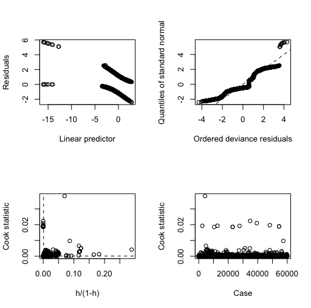

۴. با استفاده از سه نمودار خروجی مدل را نسبت به داده واقعی ارزیابی کنید.

طبق نمودارها مدل ما در تخمین منفی نسبتا خوب عمل میکند و میزان منفی ای که مثبت تخمین زده شود کم است. اما مدل در داده های مثبت به خوبی منفی نیست و بسیاری از داده های مثبت را منفی تخمین میزند.

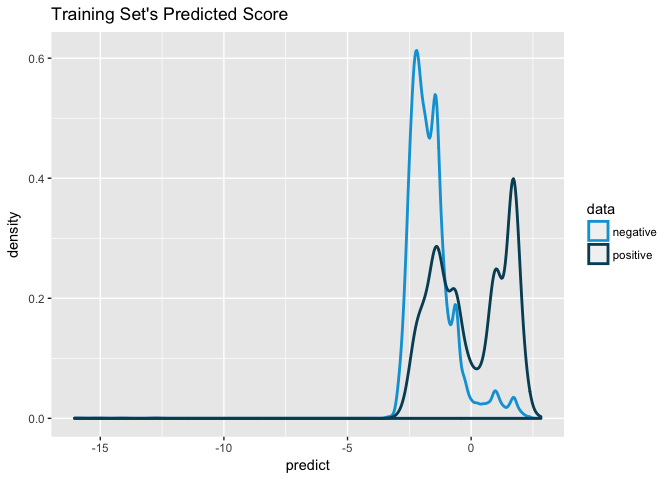

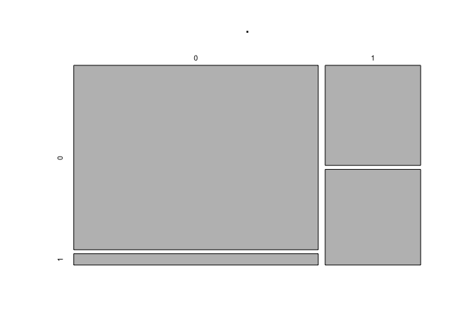

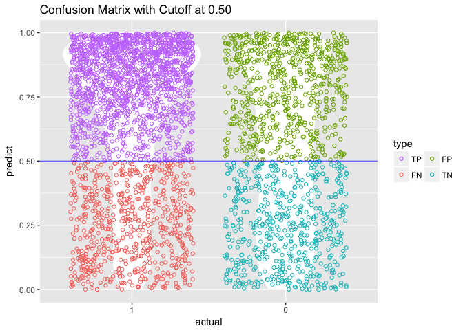

۵. ابتدا ۲۰ درصد داده را به صورت تصادفی به عنوان تست در نظر بگیرید. مدل را با استفاده از ۸۰ درصد باقی مانده برازش دهید. با استفاده از پارامتر قطع ۰.۵ نتایج را برای داده تست پیش بینی کنید. سپس کمیت های زیر را محاسبه کنید.

- P: positive samples
- N: negative samples
- TP: true positive TP (eqv. with hit)
- TN: true negative (eqv. with correct rejection)
- FP: false positive (eqv. with false alarm, Type I error)
- FN: false negative (eqv. with miss, Type II error)
- Accuracy (ACC) ACC = (TP+TN)/(P+T)
- False positive rate (FPR): 1- TN/N
- True positive rate (TPR): TP/P

مشابه آنچه در کلاس گفته شد نمایشی از چهار کمیت TN, TP,FP,FN به همراه داده ها رسم نمایید.

```
## [1] "Accuracy:"
```

```
## [1] 0.8127709
```

```
## [1] "FPR:"
```

```
## [1] 0.1867785
```

```
## [1] "TPR:"
```

```
## [1] 0.810317
```

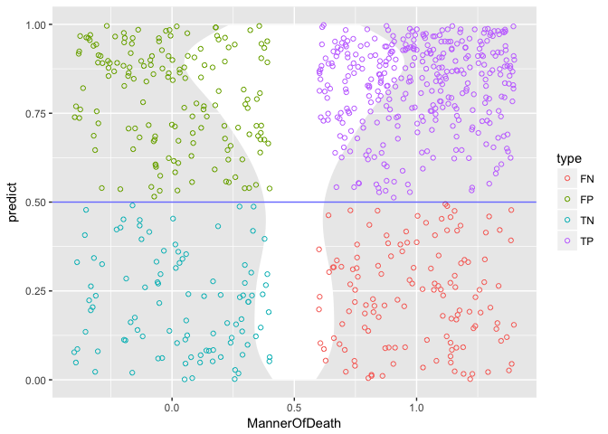

۶. نمودار صحت مدل (accuracy) را بر حسب مقادیر مختلف قطع برای داده تست رسم نمایید. کدام پارامتر قطع بالاترین صحت را در پیش بینی داراست؟

نمودار در زیر آمده است و ۱۰ مقدار برتر برای قطع نیز نشان داده شده است که با توجه به کم بودن مقادیر اول یکی از مقادیر نزدیک تر به ۰.۵ مثل ۰.۳۶ میتواند گزینه مناسب تری باشد.

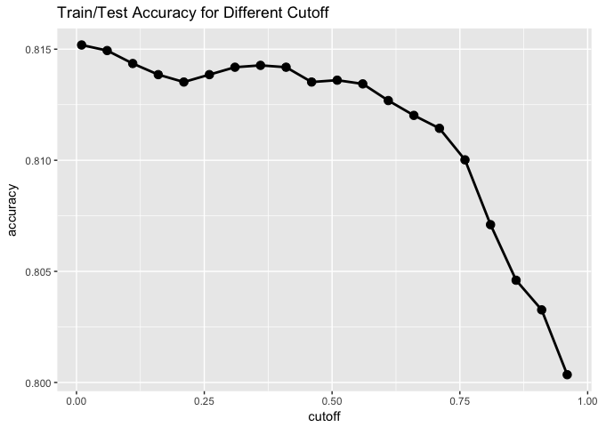

```
##    cutoff  accuracy
## 1    0.01 0.8151884
## 2    0.06 0.8149383
## 3    0.11 0.8143548
## 4    0.36 0.8142714
## 5    0.31 0.8141881
## 6    0.41 0.8141881
## 7    0.16 0.8138546
## 8    0.26 0.8138546
## 9    0.51 0.8136045
## 10   0.21 0.8135212
```

۷. نمودار ROC را برای داده های قسمت قبل رسم نمایید. همچنین نقطه مربوط به بهترین پارامتر قطع را مشخص نمایید.

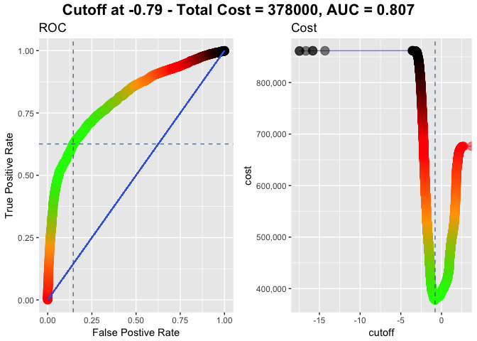

۸. با قرار دادن کمیت nfolds = 5 و با استفاده از H20 مدل مساله را بسازید و نتیجه حاصل را ارزیابی کنید.

خلاصه نتایج مدل آورده شده است. و میانگین همه نوع پارامتر اندازه گیری در انتهای مدل آمده است.

[output not shown]

[output not shown]

[output not shown]

```
## Model Details:
## ==============
##
## H2OBinomialModel: glm
## Model ID:  GLM_model_R_1524771039192_163
## GLM Model: summary
##     family  link                                regularization
## 1 binomial logit Elastic Net (alpha = 0.5, lambda = 1.956E-4 )
##   number_of_predictors_total number_of_active_predictors
## 1                         19                          16
##   number_of_iterations training_frame
## 1                    3              d
##
## Coefficients: glm coefficients
##                     names coefficients standardized_coefficients
## 1               Intercept    -0.452982                 -0.866997
## 2   MethodOfDisposition.B     0.437454                  0.437454
## 3   MethodOfDisposition.C    -0.684873                 -0.684873
## 4   MethodOfDisposition.D    -0.659483                 -0.659483
## 5   MethodOfDisposition.E     0.000000                  0.000000
## 6   MethodOfDisposition.O     0.000000                  0.000000
## 7   MethodOfDisposition.R     0.133909                  0.133909
## 8   MethodOfDisposition.U     0.000000                  0.000000
## 9         MaritalStatus.D    -0.266136                 -0.266136
## 10        MaritalStatus.M    -0.458897                 -0.458897
## 11        MaritalStatus.S     0.378029                  0.378029
## 12        MaritalStatus.U     0.336623                  0.336623
## 13        MaritalStatus.W    -0.053122                 -0.053122
## 14                  Sex.F     0.016155                  0.016155
## 15                  Sex.M    -0.015839                 -0.015839
## 16                   Race     0.002010                  0.013263
## 17 EducationReportingFlag     0.219754                  0.063937
## 18                    Age    -0.020246                 -0.508139
## 19       DayOfWeekOfDeath     0.010790                  0.021595
## 20         ResidentStatus     0.191268                  0.104071
##
## H2OBinomialMetrics: glm
## ** Reported on training data. **
##
## MSE:  0.1700348
```

[output cut: 78 more lines]

```
## ---
##                         mean           sd cv_1_valid cv_2_valid cv_3_valid
## precision          0.4427004  0.009276765 0.43700218 0.46388832 0.43456578
## r2                0.15727472 0.0040792376 0.15073693 0.16552082 0.15793751
## recall             0.7210724  0.015324416  0.7188803 0.68427336  0.7414906
## residual_deviance  12428.374    94.582344  12323.499  12292.117  12672.679
## rmse              0.41252044  0.001291192 0.41557294 0.40995935 0.41168246
## specificity        0.6446265  0.019540623 0.63260484   0.693145  0.6261937
##                   cv_4_valid cv_5_valid
## precision          0.4509804 0.42706534
## r2                 0.1612083 0.15097007
## recall             0.7162162 0.74450135
## residual_deviance  12416.705  12436.873
## rmse              0.41256627  0.4128212
## specificity        0.6558042 0.61538464
```

۹. آیا ما میتوانیم سرویسی به قضات ارایه کنیم تا با استفاده از اطلاعات مرگ بتوانند موارد مشکوک به قتل را از خودکشی تفکیک دهند؟

با توجه به نتایج قسمت قبل که accuracy حدود ۰.۶۸ بود به طور میانگین، با احتمال بالایی این مدل تخمین نسبتا درستی دارد اما چون قضاوت حساس است و باید اطمینان بالای ۹۵ درصد باشد نمیتوان کامل به این مدل استناد کرد.